# Motivación

### Recordemos la fórmula general de la longitud de arco

Supongamos una curva $y = f(x)$ definida y derivable en $[a,b]$.

1. Toma dos puntos muy próximos $x = a$ y $x = b$ con $|a-b| = d$.
2. En el plano sus imágenes son $(a,f(a))$ y $(b,f(b))$, cuya distancia euclídea es

   $$ \sqrt{|a-b|^{2} + |f(a)-f(b)|^{2}} = d \, \sqrt{\,1 + \left(\frac{f(a)-f(b)}{\,b-a\,}\right)^{2}}. $$
3. Al hacer $b \to a$ (y por tanto $d \to dx$) el cociente $\dfrac{f(a)-f(b)}{b-a}$ tiende a la derivada $f'(x)$.
4. Sumando (integrando) todas esas “pequeñas” distancias se obtiene la longitud total

   $$ L \;=\; \int_a^{b} \sqrt{\,1 + \bigl(f'(x)\bigr)^{2}} \; dx. $$

### Si calculamos la longitud de arco de $y = \sin x$ para el medio período ($x \in [0,\pi]$) tenemos:

$$ L \;=\; \int_{0}^{\pi} \sqrt{\,1 + \cos^{2}x}\; dx. $$

### La integral no admite solución elemental

1. **Cambio trigonométrico.**  
   Escribe $\cos^{2}x = 1 - \sin^{2}x$ y toma $t = \sin x$ ($dt = \cos x \, dx$). Entonces

   $$ L = \int \! \sqrt{\frac{2 - t^{2}}{1 - t^{2}}}\; dt, $$

   lo que revela la estructura típica de las [integrales elípticas](https://en.wikipedia.org/wiki/Elliptic_integral).
2. **Forma elíptica.**  
   Tras un re-escalamiento puede reescribirse como

   $$ L \;=\; \sqrt{2}\, \int_{0}^{\pi/2} \sqrt{\,1 - k^{2}\sin^{2}\theta}\; d\theta, \qquad k = \tfrac{1}{2}, $$

   que coincide con la **integral elíptica incompleta de segunda especie** $E(\phi,k)$.
3. **Teorema de Liouville.**  
   Las integrales elípticas no se expresan mediante funciones elementales (sumas, productos, exponenciales, logaritmos, etc.). Por ello

   $$ \int \sqrt{\,1 + \cos^{2}x}\; dx $$

   carece de antiderivada elemental; su valor se describe con funciones especiales o se aproxima numéricamente.

## Ejemplo 2

### Ecuación lineal de primer orden

Considera la ecuación

$$ x'(t)\;+\;\frac{2}{1+t^{4}}\,x(t)\;=\;\sin(t), \qquad t\ge 0, $$

que está en la forma estándar $x' + p(t)\,x = q(t)$ con

$$ p(t)=\frac{2}{1+t^{4}}, \qquad q(t)=\sin(t). $$

### Calculando el factor integrante tenemos:

$$ \mu(t)=\exp\!\Bigl(\int p(t)\,dt\Bigr) =\exp\!\Bigl(\int\frac{2\,dt}{1+t^{4}}\Bigr). $$

Tras factorizar $1+t^{4}=(t^{2}+\sqrt{2}\,t+1)(t^{2}-\sqrt{2}\,t+1)$ y usar fracciones parciales se obtiene

$$ \mu(t)=\Biggl\{ \frac{ \exp\!\bigl[2\tan^{-1}\!\bigl(1+\sqrt2\,t\bigr)\bigr]\, \bigl(t^{2}+\sqrt{2}\,t+1\bigr) }{ \exp\!\bigl[2\tan^{-1}\!\bigl(1-\sqrt2\,t\bigr)\bigr]\, \bigl(t^{2}-\sqrt{2}\,t+1\bigr) } \Biggr\}^{1/(2\sqrt{2})}, $$

### Al multiplicar la ecuación original por $\mu(t)$ queda exacta:

$$ \frac{d}{dt}\bigl[\mu(t)\,x(t)\bigr]\;=\;\mu(t)\,\sin(t). $$

Integrando de $0$ a $t$ y llamando $A=g(0)\,x(0)$ se obtiene

$$ x(t)\;=\;A\,\mu(t)\;+\;g(t) \int_{0}^{t}\frac{\sin(s)}{\mu(s)}\,ds. $$

### La integral no se puede expresar con [funciones elementales](https://en.wikipedia.org/wiki/Nonelementary_integral)

Aunque

$$ \int_{0}^{t}\frac{\sin(s)}{\mu(s)}\,ds $$

**existe** para todo $t\ge 0$, su antiderivada combina $\sin(s)$ con  
$\exp\!\bigl(\int 2/(1+s^{4})\,ds\bigr)$, que ya involucra arcotangentes y términos racionales no polinomiales.  
El **teorema de Liouville** sobre integración elemental indica que tales combinaciones no se simplifican a funciones elementales (polinomios, exponenciales, logaritmos, trigonométricas, etc.).

En consecuencia, la integral solo puede

1. describirse mediante **funciones especiales** más allá del repertorio elemental, o
2. **evaluarse numéricamente** (por ejemplo, con reglas de cuadratura o resolviendo directamente el problema de valor inicial con Runge–Kutta).

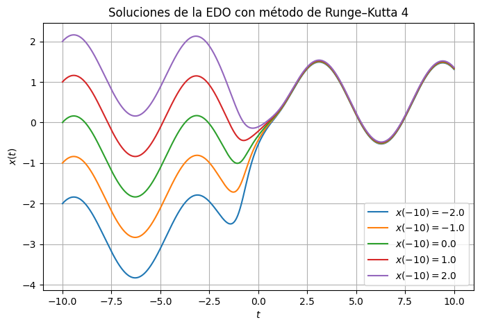

```python
import numpy as np
import matplotlib.pyplot as plt

# Define the derivative function for the ODE:
# x' = sin(t) - (2 / (1 + t^4)) * x
def f(t, x):
    return np.sin(t) - (2.0 / (1.0 + t**4)) * x

# Classical fourth‑order Runge–Kutta step
def rk4_step(f, t, x, h):
    k1 = f(t, x)
    k2 = f(t + 0.5 * h, x + 0.5 * h * k1)
    k3 = f(t + 0.5 * h, x + 0.5 * h * k2)
    k4 = f(t + h, x + h * k3)
    return x + (h / 6.0) * (k1 + 2*k2 + 2*k3 + k4)

# Integrator over a time grid
def runge_kutta4(f, t0, x0, t_end, h):
    n_steps = int(np.ceil((t_end - t0) / h))
    t_values = np.zeros(n_steps + 1)
    x_values = np.zeros(n_steps + 1)
    t_values[0] = t0
    x_values[0] = x0
    t = t0
    x = x0
    for i in range(1, n_steps + 1):
        if t + h > t_end:
            h = t_end - t  # adjust last step
        x = rk4_step(f, t, x, h)
        t += h
        t_values[i] = t
        x_values[i] = x
    return t_values, x_values

# Parameters for the integration
t0 = -10.0
t_end = 10.0
h = 0.01
initial_conditions = [-2.0,-1.0, 0.0, 1.0,2.0]

# Plot trajectories for different initial conditions
plt.figure(figsize=(8, 5))
for x0 in initial_conditions:
    t_vals, x_vals = runge_kutta4(f, t0, x0, t_end, h)
    plt.plot(t_vals, x_vals, label=f"$x(-10)={x0}$")

plt.xlabel("$t$")
plt.ylabel("$x(t)$")
plt.title("Soluciones de la EDO con método de Runge–Kutta 4")
plt.legend()
plt.grid(True)
plt.show()
```

## Ejemplo 3

Sea la ecuación diferencial de primer orden

$$ y'(t)=\exp\bigl(-t\,y(t)^{4}\bigr), \qquad t\ge 0, $$

con alguna condición inicial $y(0)=y_{0}$.

#### 1. ¿Por qué no admite solución analítica elemental?

1. **No es lineal ni separable.**  
   Para separar variables necesitaríamos escribir $y' = g(t)\,h(y)$ y luego  
   $\displaystyle \int \frac{dy}{h(y)} = \int g(t)\,dt$.  
   Aquí, en cambio, $t$ y $y$ aparecen *dentro* del mismo exponente:  
   $\exp(-t\,y^{4})$. No es posible aislar los factores dependientes solo de $t$ o solo de $y$.
2. **Cambio de variables ineficaz.**  
   Recordemos que para **invertir la relación** y escribir $t$ como función de $y$ partimos de la ecuación original

   $$ \frac{dy}{dt}=e^{-t\,y^{4}}. $$

   Siempre que $dy/dt\neq 0$:

   $$ \frac{dt}{dy} \;=\; \frac{1}{\displaystyle \frac{dy}{dt}} \;=\; e^{\,t\,y^{4}}. $$

   Ahora $t$ es la incógnita y $y$ la variable independiente; escribimos $t=t(y)$ y la ecuación queda

   $$ \; \dfrac{dt}{dy}=e^{\,t(y)\,y^{4}} \; $$
   ecuación implícita que tampoco se integra con funciones elementales porque $t$ sigue apareciendo en ambos lados.

#### Aproximación numérica con Runge–Kutta 4 (RK4)

El siguiente código en Python integra el problema para varios valores iniciales con paso fijo (h=0.01).

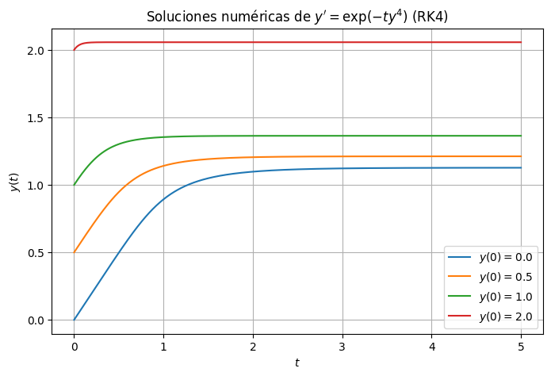

```python
import numpy as np
import matplotlib.pyplot as plt

def f(t, y):
    return np.exp(-t * y**4)          # y' = exp(-t y^4)

def rk4_step(f, t, y, h):
    k1 = f(t, y)
    k2 = f(t + 0.5*h, y + 0.5*h*k1)
    k3 = f(t + 0.5*h, y + 0.5*h*k2)
    k4 = f(t + h,   y + h*k3)
    return y + (h/6)*(k1 + 2*k2 + 2*k3 + k4)

def runge_kutta4(f, t0, y0, t_end, h):
    n = int(np.ceil((t_end - t0)/h))
    t_vals, y_vals = np.zeros(n+1), np.zeros(n+1)
    t_vals[0], y_vals[0] = t0, y0
    t, y = t0, y0
    for i in range(1, n+1):
        if t + h > t_end:              # último paso ajustado
            h = t_end - t
        y = rk4_step(f, t, y, h)
        t += h
        t_vals[i], y_vals[i] = t, y
    return t_vals, y_vals

t0, t_end, h = 0.0, 5.0, 0.01
initial_conditions = [0.0, 0.5, 1.0, 2.0]

plt.figure(figsize=(8,5))
for y0 in initial_conditions:
    t, y = runge_kutta4(f, t0, y0, t_end, h)
    plt.plot(t, y, label=f"$y(0)={y0}$")

plt.title("Soluciones numéricas de $y' = \\exp(-t y^4)$ (RK4)")
plt.xlabel("$t$")
plt.ylabel("$y(t)$")
plt.legend()
plt.grid(True)
plt.show()
```

# Bibliografía

1. Butcher, J.C. Numerical Methods for Ordinary Differential Equations (3.ª ed., Wiley, 2016).
2. Hairer, E., Nørsett, S.P. & Wanner, G. Solving Ordinary Differential Equations I: Non-stiff Problems (Springer Series in Computational Mathematics, 2.ª ed. revisada, 2008).
3. Griffiths, D.F. & Higham, D.J. Numerical Methods for Ordinary Differential Equations (Cambridge University Press, 2010).
4. Vuik, K. et al. Numerical Methods for Ordinary Differential Equations (TU Delft Open Textbook, 2023).
5. Blanes Zamora, S., Ginestar Peiró, D. & Roselló Ferragud, M.D. Introducción a los métodos numéricos para ecuaciones diferenciales (3.ª ed., Editorial UPV, 2020).
6. Gradshteyn–Ryzhik. Table of Integrals, Series, and Products. Seventh Edition.
7. Malumbres, J.L.V. Métodos clásicos de resolución de ecuaciones diferenciales ordinarias. 1996. Universidad de la Rioja.